# Random Forest- Targeted

MYC

11/24/2021

Interesting results from the P2 Random Forest ML application, Try more targeted variables

Path to data

```r
#note the use of the here() package and not absolute paths
data_location <- here::here("data","processed_data","P2-20211029.rds")
#read and load data.
```

Import P2 data

```r
P2<- readRDS(data_location)
```

Add to the data – Fix so we add a categorical aspect to Ct values- simplicity make Detected/Yes (< 37.9) and Undetected/No (>38)

```r
P2.minus1<-
  P2%>%
  filter(Tool!="B")%>% #remove B because this is actually a -3 dilution. Looking specifically at -1, keep SD range.
  mutate(
# if greater than ct 38, this is a negative detection, thus less 38 is a positive in detection
    Ct.Cat = ifelse(Ct >=38,"No","Yes"),
# There are some NAs, they are undetectable, change only in the Ct.Cat to No as a factor
    Ct.Cat=ifelse(is.na(Ct.Cat), "No",Ct.Cat),
# These are factors so mutate the chr to fctrs
    Ct.Cat=factor(Ct.Cat)
    )%>%
#Remove/adjust so there are no character based factors
    select(RH,TEMP, Method, Tool, Input, Detector, Ct, Ct.Cat,Dilution)%>%
  na.omit()

summary(P2.minus1)
```

```
##        RH             TEMP       Method          Tool         Input
##  Min.   :38.70   Min.   :24.83   CDC: 73   A       :143   Min.   : 300
##  1st Qu.:38.70   1st Qu.:24.83   NTP:185   SD      : 92   1st Qu.: 300
##  Median :41.20   Median :25.15   PCR:  0   POS.CTRL: 23   Median : 300
##  Mean   :40.63   Mean   :25.23                     :  0   Mean   :1523
##  3rd Qu.:42.05   3rd Qu.:25.70             B       :  0   3rd Qu.:1000
##  Max.   :42.05   Max.   :25.70             NEG.CTRL:  0   Max.   :7000
##                                            (Other) :  0
##      Detector         Ct        Ct.Cat       Dilution
##  N1 Probe:126   Min.   :16.59   No :  1   Min.   :-4.000
##  N2 Probe:132   1st Qu.:24.05   Yes:257   1st Qu.:-2.000
##                 Median :26.08             Median :-1.000
##                 Mean   :25.75             Mean   :-1.547
##                 3rd Qu.:27.74             3rd Qu.:-1.000
##                 Max.   :38.68             Max.   :-1.000
##
```

Set Seed for reproducibility

```r
# Fix the random numbers by setting the seed
set.seed(123)
# This enables the analysis to be reproducible when random numbers are used
```

1. Data splitting into training and testing sets (Random sampling)
2. Training
3. Testing

```r
# Put 3/4 of the data into the training set; this leaves 1/4 of the data to be used to test
data_split2 <- initial_split(P2.minus1, prop = 3/4)

## Create data frames for the two sets:
train_data2 <- training(data_split2)
test_data2  <- testing(data_split2)
```

```r
#View the train and test data
glimpse(train_data2)
```

```
## Rows: 193
## Columns: 9
## $ RH       <dbl> 38.70, 41.20, 38.70, 42.05, 41.20, 42.05, 41.20, 38.70, 38.70~
## $ TEMP     <dbl> 24.83, 25.70, 24.83, 25.15, 25.70, 25.15, 25.70, 24.83, 24.83~
## $ Method   <fct> NTP, CDC, CDC, NTP, NTP, NTP, NTP, NTP, NTP, NTP, NTP, NTP, C~
## $ Tool     <fct> SD, A, SD, A, SD, SD, A, A, SD, A, A, SD, SD, SD, POS.CTRL, S~
## $ Input    <dbl> 300, 300, 300, 6900, 300, 300, 300, 1000, 300, 6900, 6900, 10~
## $ Detector <fct> N1 Probe, N1 Probe, N2 Probe, N2 Probe, N1 Probe, N2 Probe, N~
## $ Ct       <dbl> 20.1409, 27.0894, 20.4853, 26.5957, 25.4376, 17.3671, 38.6768~
## $ Ct.Cat   <fct> Yes, Yes, Yes, Yes, Yes, Yes, No, Yes, Yes, Yes, Yes, Yes, Ye~
## $ Dilution <dbl> -2, -1, -2, -1, -4, -1, -1, -1, -2, -1, -1, -1, -3, -2, -1, -~
```

```r
glimpse(test_data2)
```

```
## Rows: 65
## Columns: 9
## $ RH       <dbl> 41.20, 41.20, 41.20, 41.20, 41.20, 41.20, 41.20, 41.20, 41.20~
## $ TEMP     <dbl> 25.70, 25.70, 25.70, 25.70, 25.70, 25.70, 25.70, 25.70, 25.70~
## $ Method   <fct> CDC, CDC, CDC, CDC, NTP, NTP, CDC, NTP, NTP, NTP, CDC, NTP, N~
## $ Tool     <fct> SD, SD, A, A, A, A, POS.CTRL, SD, SD, SD, A, SD, A, A, A, SD,~
## $ Input    <dbl> 300, 300, 300, 300, 300, 300, 300, 300, 300, 300, 300, 1000, ~
## $ Detector <fct> N1 Probe, N1 Probe, N1 Probe, N1 Probe, N1 Probe, N1 Probe, N~
## $ Ct       <dbl> 23.2780, 25.0061, 26.7743, 27.1725, 28.5065, 29.0204, 24.9828~
## $ Ct.Cat   <fct> Yes, Yes, Yes, Yes, Yes, Yes, Yes, Yes, Yes, Yes, Yes, Yes, Y~
## $ Dilution <dbl> -3, -2, -1, -1, -1, -1, -1, -4, -3, -1, -1, -2, -1, -1, -1, -~
```

```r
table(train_data2$Method)%>%
  prop.table()
```

```
##
##       CDC       NTP       PCR
## 0.2694301 0.7305699 0.0000000
```

```r
table(test_data2$Method)%>%
  prop.table()
```

```
##
##       CDC       NTP       PCR
## 0.3230769 0.6769231 0.0000000
```

2. Creating Models

# Ct value or Detection as function of method and inital dilution

Detection ~ Method + Dilution

# Ct value or detection for all precitcors (short hand for all predictors)

Detection~., data=P2.minus1

2.1. Many engines Examples

```r
# fit linear model
lm_lm    <- lm(Ct ~ ., data = P2.minus1)
# fit general linear model
lm_glm   <- glm(Ct ~ ., data = P2.minus1,
                family = gaussian)
#########
#<atempt to use later>
# meta engine (aggregator) method=<method name>; see parsnips
lm_caret <- train(Ct ~ Method + Dilution + Input, data = P2.minus1,
                 method = "glm")
```

[output not shown]

[output cut: 19 more lines]

[output not shown]

2.4. Resampling - CV

```r
# create bootstrap resample object from training data
cv_data_boots <- bootstraps(train_data2, v=5)
print(cv_data_boots)
```

```
## # Bootstrap sampling
## # A tibble: 25 x 2
##    splits           id
##    <list>           <chr>
##  1 <split [193/67]> Bootstrap01
##  2 <split [193/71]> Bootstrap02
##  3 <split [193/71]> Bootstrap03
##  4 <split [193/65]> Bootstrap04
##  5 <split [193/72]> Bootstrap05
##  6 <split [193/66]> Bootstrap06
##  7 <split [193/73]> Bootstrap07
##  8 <split [193/66]> Bootstrap08
##  9 <split [193/69]> Bootstrap09
## 10 <split [193/67]> Bootstrap10
## # ... with 15 more rows
```

Preprocessing Using parsnips to create a recipe for fitting the model No standardization adding dummy variables are added

```r
fit_recipe2 <-
# set a recipe specific to the Dilution and Input
  recipe(Ct ~Dilution+Input+Method, data = P2.minus1) %>%
# code all categorical variables as dummy variables
  step_dummy(all_nominal())

print(fit_recipe2)
```

```
## Recipe
##
## Inputs:
##
##       role #variables
##    outcome          1
##  predictor          3
##
## Operations:
##
## Dummy variables from all_nominal()
```

Null Model Ct is a continuions outcome of numbers– need to use RMSE as performance metric.

```r
RMSE_null_train2 <- sqrt(sum( (train_data2$Ct - mean(train_data2$Ct))^2 )/nrow(train_data2))

RMSE_null_test2 <- sqrt(sum( (test_data2$Ct - mean(test_data2$Ct))^2 )/nrow(test_data2))

print(RMSE_null_train2)
```

```
## [1] 4.181168
```

```r
predict(lm_glm, train_data=Ct)
```

[output not shown]

[output cut: 11 more lines]

[output not shown]

```r
rf_model2 <- rand_forest() %>%
  set_args(mtry = tune(),
    trees = tune(),
    min_n = tune()
  ) %>%
  # select the engine/package that underlies the model
  set_engine("ranger",
             num.threads = 18, #for some reason for RF, we need to set this in the engine too
             importance = "permutation") %>%
  # choose either the continuous regression or binary classification mode
  set_mode("regression")
```

```r
#workflow
rf_wf2 <- workflow() %>%
  add_model(rf_model2) %>%
  add_recipe(fit_recipe2)
```

Try bootstrapping in CV workflow

```r
#tuning grid
rf_grid2  <- expand.grid(mtry = c(3, 4, 5, 6), min_n = c(40,50,60), trees = c(500,1000)  )

# tune the model, optimizing RMSE
rf_tune_res2 <- rf_wf2 %>%
  tune_grid(
            resamples = cv_data_boots, #CV object
            grid = rf_grid2, # grid of values to try
            metrics = metric_set(rmse)
  )
```

[output not shown]

[output not shown]

[output not shown]

[output not shown]

[output not shown]

[output not shown]

[output not shown]

[output not shown]

[output not shown]

[output not shown]

[output not shown]

[output not shown]

[output not shown]

[output not shown]

[output not shown]

[output not shown]

[output not shown]

[output not shown]

[output not shown]

[output not shown]

[output not shown]

[output not shown]

[output not shown]

[output not shown]

[output not shown]

[output not shown]

[output not shown]

[output not shown]

[output not shown]

[output not shown]

[output not shown]

[output not shown]

[output not shown]

[output not shown]

[output not shown]

[output not shown]

[output not shown]

[output not shown]

[output not shown]

[output not shown]

[output not shown]

[output not shown]

[output not shown]

[output not shown]

[output not shown]

[output not shown]

[output not shown]

[output not shown]

[output not shown]

[output not shown]

[output not shown]

[output not shown]

[output not shown]

[output not shown]

[output not shown]

[output not shown]

[output not shown]

[output not shown]

[output not shown]

[output not shown]

[output not shown]

[output not shown]

[output not shown]

[output not shown]

[output not shown]

[output not shown]

[output not shown]

[output not shown]

[output not shown]

[output not shown]

[output not shown]

[output not shown]

[output not shown]

[output not shown]

[output not shown]

[output not shown]

[output not shown]

[output not shown]

[output not shown]

[output not shown]

[output not shown]

[output not shown]

[output not shown]

[output not shown]

[output not shown]

[output not shown]

[output not shown]

[output not shown]

[output not shown]

[output not shown]

[output not shown]

[output not shown]

[output not shown]

[output not shown]

[output not shown]

[output not shown]

[output not shown]

[output not shown]

[output not shown]

[output not shown]

[output not shown]

[output not shown]

[output not shown]

[output not shown]

[output not shown]

[output not shown]

[output not shown]

[output not shown]

[output not shown]

[output not shown]

[output not shown]

[output not shown]

[output not shown]

[output not shown]

[output not shown]

[output not shown]

[output not shown]

[output not shown]

[output not shown]

[output not shown]

[output not shown]

[output not shown]

[output not shown]

[output not shown]

[output not shown]

[output not shown]

[output not shown]

[output not shown]

[output not shown]

[output not shown]

[output not shown]

[output not shown]

[output not shown]

[output not shown]

[output not shown]

[output not shown]

[output not shown]

[output not shown]

[output not shown]

[output not shown]

[output not shown]

[output not shown]

[output not shown]

[output not shown]

[output not shown]

[output not shown]

[output not shown]

[output not shown]

[output not shown]

[output not shown]

[output not shown]

[output not shown]

[output not shown]

[output not shown]

[output not shown]

[output not shown]

[output not shown]

[output not shown]

[output not shown]

[output not shown]

[output not shown]

[output not shown]

[output not shown]

[output not shown]

[output not shown]

[output not shown]

[output not shown]

[output not shown]

[output not shown]

[output not shown]

[output not shown]

[output not shown]

[output not shown]

[output not shown]

[output not shown]

[output not shown]

[output not shown]

[output not shown]

[output not shown]

[output not shown]

[output not shown]

[output not shown]

[output not shown]

[output not shown]

[output not shown]

[output not shown]

[output not shown]

[output not shown]

[output not shown]

[output not shown]

[output not shown]

[output not shown]

[output not shown]

[output not shown]

[output not shown]

[output not shown]

[output not shown]

[output not shown]

[output not shown]

[output not shown]

[output not shown]

[output not shown]

[output not shown]

[output not shown]

[output not shown]

[output not shown]

[output not shown]

[output not shown]

[output not shown]

[output not shown]

[output not shown]

[output not shown]

[output not shown]

[output not shown]

[output not shown]

[output not shown]

[output not shown]

[output not shown]

[output not shown]

[output not shown]

[output not shown]

[output not shown]

[output not shown]

[output not shown]

[output not shown]

[output not shown]

[output not shown]

[output not shown]

[output not shown]

[output not shown]

[output not shown]

[output not shown]

[output not shown]

[output not shown]

[output not shown]

[output not shown]

[output not shown]

[output not shown]

[output not shown]

[output not shown]

[output not shown]

[output not shown]

[output not shown]

[output not shown]

[output not shown]

[output not shown]

[output not shown]

[output not shown]

[output not shown]

[output not shown]

[output not shown]

[output not shown]

[output not shown]

[output not shown]

[output not shown]

[output not shown]

[output not shown]

[output not shown]

[output not shown]

[output not shown]

[output not shown]

[output not shown]

[output not shown]

[output not shown]

[output not shown]

[output not shown]

[output not shown]

[output not shown]

[output not shown]

[output not shown]

[output not shown]

[output not shown]

[output not shown]

[output not shown]

[output not shown]

[output not shown]

[output not shown]

[output not shown]

[output not shown]

[output not shown]

[output not shown]

[output not shown]

[output not shown]

[output not shown]

[output not shown]

[output not shown]

[output not shown]

[output not shown]

[output not shown]

[output not shown]

[output not shown]

[output not shown]

[output not shown]

[output not shown]

[output not shown]

[output not shown]

[output not shown]

[output not shown]

[output not shown]

[output not shown]

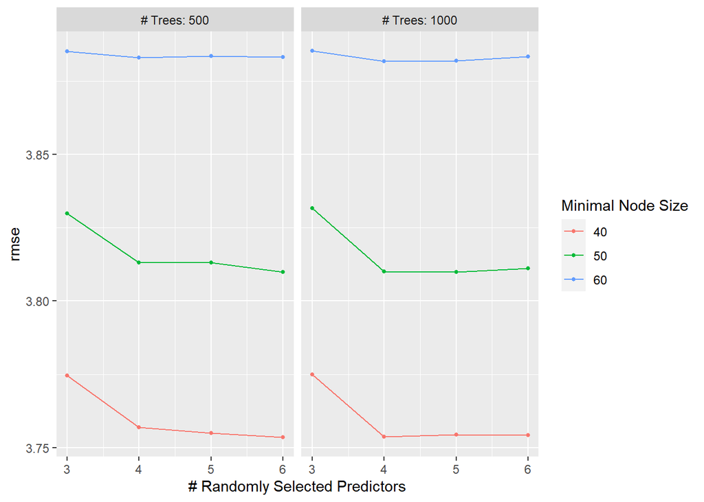

```r
#see a plot of performance for different tuning parameters
rf_tune_res2 %>% autoplot()
```

```r
# get the tuned model that performs best
best_rf2 <- rf_tune_res2 %>%  select_best(metric = "rmse")

# finalize workflow with best model
best_rf_wf2 <- rf_wf2 %>% finalize_workflow(best_rf2)

# fitting best performing model
best_rf_fit2 <- best_rf_wf2 %>%
  fit(data = train_data2)
rf_pred2 <- predict(best_rf_fit2, train_data2)
```

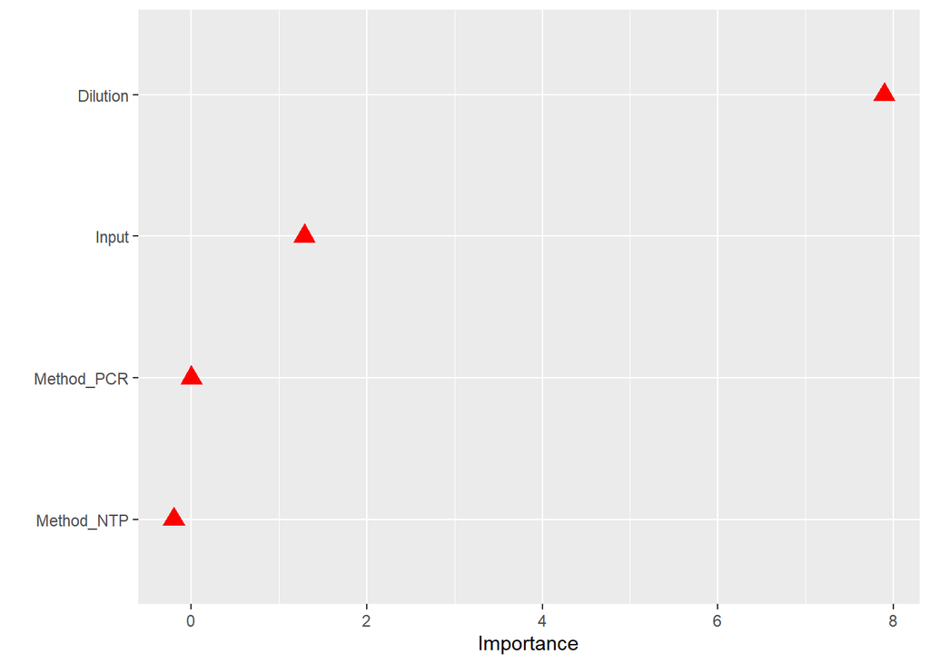

```r
#pull out the fit object
x2 <- best_rf_fit2$fit$fit$fit
#plot variable importance
P2RFBestFitminus1<-vip::vip(x2, num_features = 10, geom="point", aesthetics = list(color = "red", shape = 17, size = 4))
print(P2RFBestFitminus1)
```

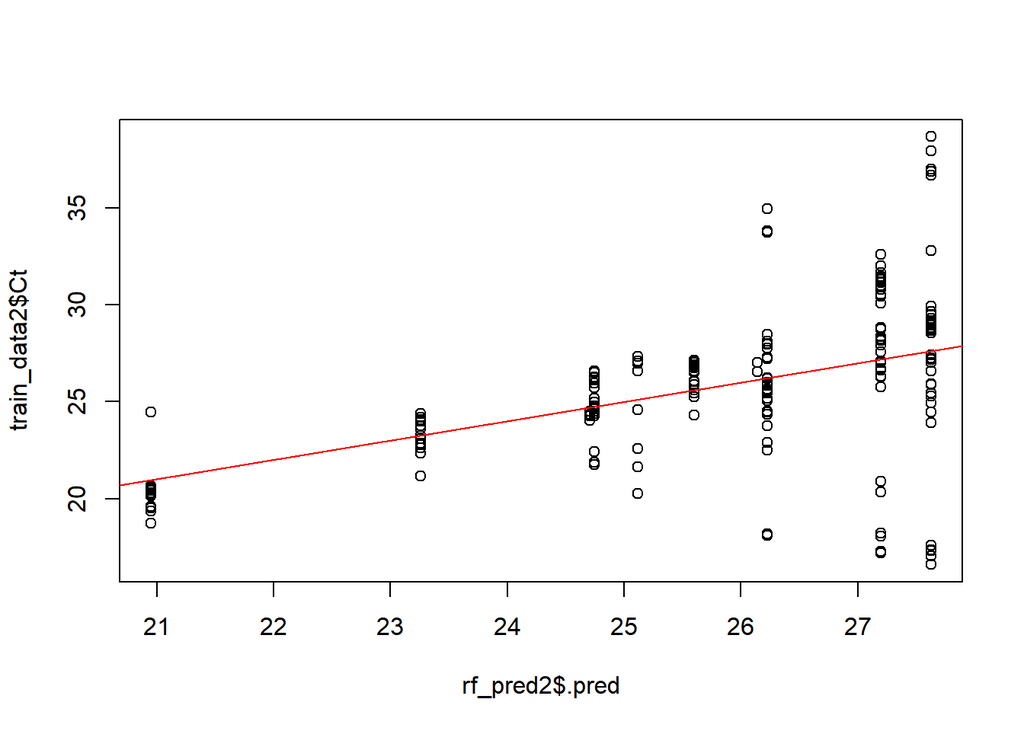

```r
#save figure
figure_file = here("results","P2-RF-BestFit-minus1.png")
ggsave(filename = figure_file, plot=P2RFBestFitminus1)
#predicted versus observed
plot(rf_pred2$.pred,train_data2$Ct)
abline(a=0,b=1, col = 'red') #45 degree line, along which the results should fall
```

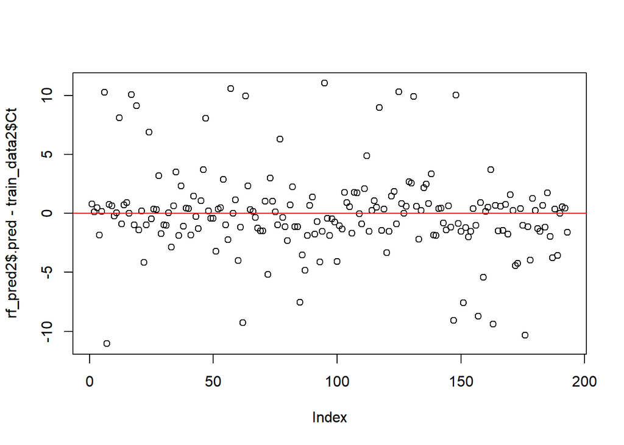

```r
#residuals
plot(rf_pred2$.pred-train_data2$Ct)
abline(a=0,b=0, col = 'red') #straight line, along which the results should fall
```

```r
rf_perfomance2 <- rf_tune_res2 %>% show_best(n = 5)
print(rf_perfomance2)
```

```
## # A tibble: 5 x 9
##    mtry trees min_n .metric .estimator  mean     n std_err .config
##   <dbl> <dbl> <dbl> <chr>   <chr>      <dbl> <int>   <dbl> <chr>
## 1     6   500    40 rmse    standard    3.75    25  0.0751 Preprocessor1_Model04
## 2     4  1000    40 rmse    standard    3.75    25  0.0757 Preprocessor1_Model14
## 3     6  1000    40 rmse    standard    3.75    25  0.0754 Preprocessor1_Model16
## 4     5  1000    40 rmse    standard    3.75    25  0.0755 Preprocessor1_Model15
## 5     5   500    40 rmse    standard    3.75    25  0.0751 Preprocessor1_Model03
```

# Try to see if Best Tree can show us something

Tree model

```r
tree_model2 <-  decision_tree() %>%
  set_args( cost_complexity = tune(), tree_depth = tune(), min_n = tune()) %>%
  set_engine("rpart") %>%
  set_mode("regression")
```

Workflow

```r
#set workflow
tree_wf2 <- workflow() %>%
  add_model(tree_model2) %>%
  add_recipe(fit_recipe2)
```

Tree Model

```r
#tuning grid
tree_grid2 <- dials::grid_regular(cost_complexity(), tree_depth(), min_n(), levels = 5)
#tune the model
tree_tune_res2 <- tree_wf2 %>%
  tune::tune_grid(
    resamples = cv_data_boots,
    grid = tree_grid2,
    metrics = yardstick::metric_set(rmse)
  )
```

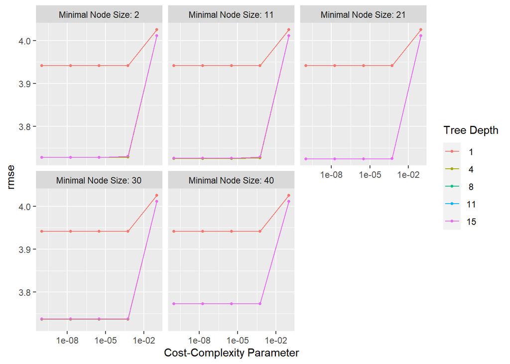

```r
#see a plot of performance for different tuning parameters
tree_tune_res2 %>% autoplot()
```

```r
# get the tuned model that performs best
best_tree2 <- tree_tune_res2 %>%  select_best(metric = "rmse")
# finalize workflow with best model
best_tree_wf2 <- tree_wf2 %>% finalize_workflow(best_tree2)
# fitting best performing model
best_tree_fit2 <- best_tree_wf2 %>%
                 fit(data = train_data2)
#predicting outcomes for final model
tree_pred2 <- predict(best_tree_fit2, train_data2)
```

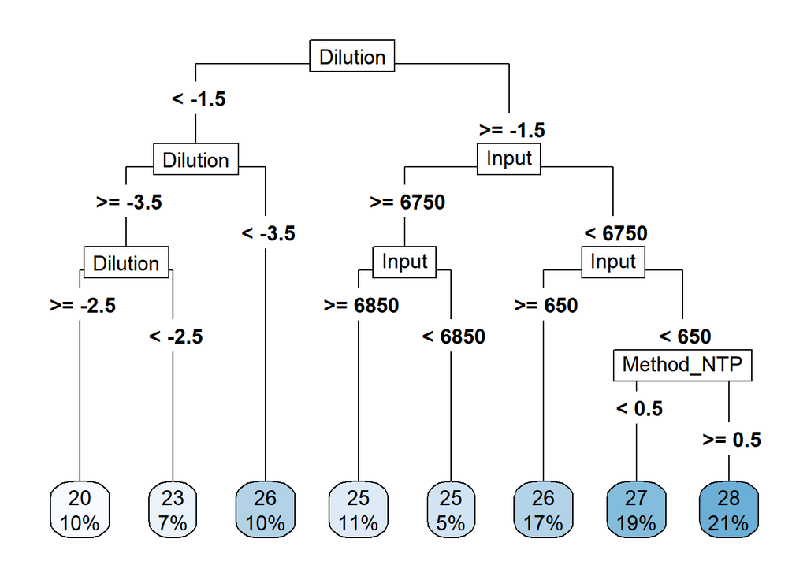

```r
minusTree<-
  rpart.plot(extract_fit_parsnip(best_tree_fit2)$fit,type = 5, tweak = 1.2)
```

```r
print(minusTree)
```

[output not shown]

[output cut: 70 more lines]

[output not shown]

Each node shows: predicted values, and percentage of observations in node. So if the dilution is still the lead in the effects of the Ct. - Makes sense as that’s the spiking/manipulating level If the dilution is greater than -1.5, effects of the input factor strongly in the Ct recovery, with a little input from the method if the input is less than 650uL